# Bats_counttable

```r
#import libraries to be able to build table count for each gene
library(tximport) #for tximport
library(DESeq2) #for the differential expression analysis
library(biomaRt) #to automatically request ensembl identifiers
library(dplyr) #for the manipulation of data frames
library(tidyr)
library(data.table)
```

```r
library(ggplot2) #for graphs
library(pheatmap) #for pretty heatmaps

#set working directory
setwd("/ifb/data/mydatalocal/data_from_ftp")
```

# Building a count table per gene

Based on the quantifications obtained with salmon, we now want to obtain the expression level for each gene (and not just each transcript or isoform). We build a count table.

Import the files, we need a variable that contains the name of the files quant.sf

```r
dir <- "/ifb/data/mydatalocal/data_from_ftp/outputs_salmon" #the directory where we look for the files
all_files <- list.files(dir)

#get the quant.sf files for all samples
#initialisation
files_Lib <- c()
names_file <- c()
i <- 1

#loop to get all the files in the same place
for (name in all_files) {
    if (grepl("salmon_Lib",as.character(name))==TRUE) { #take all the files that contain "salmon_Lib" in their name
      files_Lib[i] <-  file.path(dir,name,"quant.sf", fsep="/") #add the path for the file
      names_file[i] <- c(name) #add the name of the file
      i <- i+1
      }
  }

names(files_Lib) <- names_file #give them names
```

Now we build reading table from the trinity gene trans map, to have the correspondance between gene and transcript.

```r
Tab_trini <- read.table("/ifb/data/mydatalocal/data_from_ftp/trinity_data/Trinity_RF.fasta.gene_trans_map") #get the fasta.gene_trans_map
names(Tab_trini) <- c("GENEID","TXNAME") #to have the right column names
Tab_trini <- Tab_trini[,c(2,1)] #to have the right order: TXNAME as first column, GENEID as second
```

Now let’s build a table with the count from each gene from the outputs of salmon

```r
txi <- tximport(files_Lib, type = "salmon", tx2gene = Tab_trini) #makes the correspondence between isoforms and genes, and crosses it with the quantification by salmon to obtain a count table.
```

```
## reading in files with read_tsv
```

```
## 1 2 3 4 5 6
## summarizing abundance
## summarizing counts
## summarizing length
```

```r
names(txi) #outputs, we obtained 3 tables: abundance, counts, and length
```

```
## [1] "abundance"           "counts"              "length"
## [4] "countsFromAbundance"
```

```r
head(txi$counts) #what's interesting for DESeq is the counts
```

```
##                   salmon_Lib1_31_20_S1 salmon_Lib2_31_20_S2
## TRINITY_DN0_c0_g1                    0                    0
## TRINITY_DN0_c0_g2                    0                    0
## TRINITY_DN0_c1_g2                    5                    0
## TRINITY_DN0_c3_g1                    0                    0
## TRINITY_DN0_c4_g1                    0                    2
## TRINITY_DN0_c5_g1                   16                    8
##                   salmon_Lib3_31_20_S3 salmon_Lib4_31_20_S4
## TRINITY_DN0_c0_g1                    1                    0
## TRINITY_DN0_c0_g2                    0                    0
## TRINITY_DN0_c1_g2                    2                    2
## TRINITY_DN0_c3_g1                    0                    1
## TRINITY_DN0_c4_g1                    0                    0
## TRINITY_DN0_c5_g1                    7                    3
##                   salmon_Lib5_31_20_S5 salmon_Lib6_31_20_S6
## TRINITY_DN0_c0_g1                    0                    0
## TRINITY_DN0_c0_g2                    4                    2
## TRINITY_DN0_c1_g2                    2                    1
## TRINITY_DN0_c3_g1                    3                    0
## TRINITY_DN0_c4_g1                    2                    0
## TRINITY_DN0_c5_g1                    7                    8
```

# Differential Expression analysis

Now let’s use DESeq

```r
#build table of correspondence which sample is + or - IFN
samp.name <- colnames(txi$counts)
samp.type <- factor(rep(c("CTL", "IFN"),each= 3)) #3 first are control, 3 last are +IFN
samples <- data.frame(run=samp.name,condition=samp.type)

#now build DESeq object (dds)
ddsTxi <- DESeqDataSetFromTximport(txi, colData = samples, design = ~ condition)
```

```
## using counts and average transcript lengths from tximport
```

```r
#Run DEseq
dds <- DESeq(ddsTxi)
```

```
## using 'avgTxLength' from assays(dds), correcting for library size
```

```r
res <- results(dds)
#res
#save the table
#write.table(res,"/ifb/data/mydatalocal/data_from_ftp/DESeq/DESeqRes.tab")

#count number of significative p-values
table(res$padj <0.05) #number of tests that are under the threshold of 0.05 #1457
```

```
##
##  FALSE   TRUE
## 294322   1457
```

Now we do control quality, and verify that there is no abnormality with the replicates (samples from the same conditions have to be closer than different conditions)

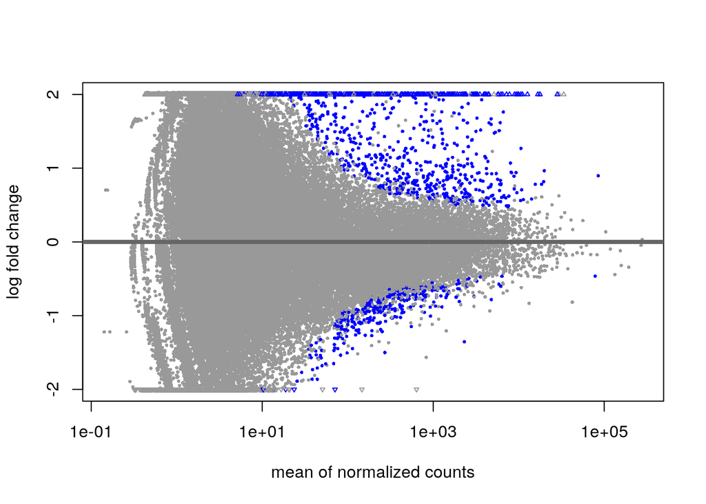

```r
#MA-plot
plotMA(res, ylim=c(-2,2))
```

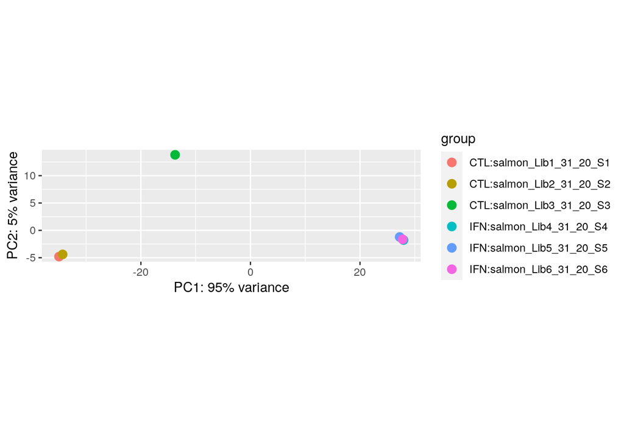

```r
#We see a high density of points (that correspond to the high number of genes obtained after assembly), and this plot confirms that the significantly differentially expressed genes have a higher fold change that the others. We also can see that there are more upregulated genes than downregulated genes.

#PCA
vsd <- vst(dds, blind=FALSE) #DESeq transform (variance stabilizing transformation)
plotPCA(vsd, intgroup=c("condition","run"))
```

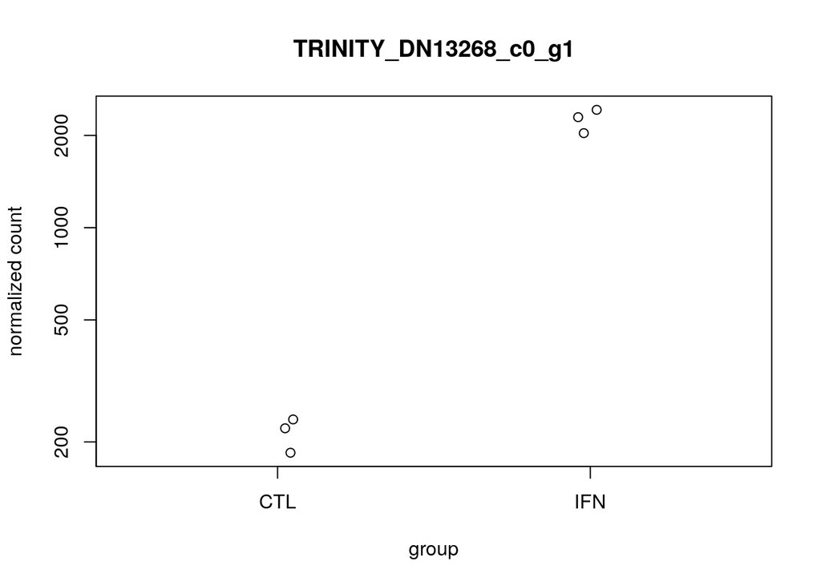

```r
#The Lib3 (CTL) is an outlier, and is not grouped with the other samples from the same condition. It can be explained because the RNA library was built a different day from the 2 others. -> We redo the DESeq analysis only on Lib1,2,4,5 and 6 (cf Bats_DEseq_without3.rmd)

#To have an idea of what the results can look like for a gene, let's plot the counts for one gene (we choose the one with the lowest adjusted p value)
plotCounts(dds, gene=which.min(res$padj), intgroup="condition")
```

Now we want to cross the results of Blast with the outputs from DEseq, in order to identify the names of all the genes (based on their corresponding human CDS)

```r
#Import Blast table
Blast <- read.table("/ifb/data/mydatalocal/data_from_ftp/blast_data/DataBats.blast")

#now we make the correspondence between ENSEMBL identifiers and external human gene names, using biomaRt
#match gene/transcript names
ensembl <- useEnsembl(biomart = "genes", dataset = "hsapiens_gene_ensembl")
tx2geneHomo = biomaRt::getBM(attributes=c('ensembl_transcript_id',
                                      'ensembl_gene_id', 'external_gene_name'),mart=ensembl)
#add gene name to the blast outputs
blastHomo<-data.table(Blast)
blastHomo<-blastHomo[, c("trid", "version") := tstrsplit(V2, ".", fixed=TRUE)][]
blastHomo<-blastHomo[, c("gene", "alttr") := tstrsplit(V1, "_i", fixed=TRUE)][]

blastHomo1 <- blastHomo%>% group_by(gene)%>% slice_max(order_by = V12, n = 1, with_ties = TRUE)

blastHomoName<-merge(tx2geneHomo,blastHomo1,by.x="ensembl_transcript_id",by.y="trid") #to merge the 2 dataframe, one with the Blast output and ensembl names (blastHomo1), and one with the ensemble and external gene names (tx2gneHomo)

blastHomoNameUniq<-unique(blastHomoName[,c("ensembl_gene_id","external_gene_name","gene")]) #unique, to remove the duplicates

#associate our DE results with gene names from human
resUsName=merge(as.data.frame(res),blastHomoNameUniq,by.x=0,by.y="gene")
#view(ResUsName)
#save this table
#write.csv(resUsName,file="/ifb/data/mydatalocal/data_from_ftp/DESeq/Tab_foldchange_genes.csv")
```

# Analyze the data

Number of genes up and down regulated

```r
table(resUsName$padj <0.05) #Number of genes identified as significatively differently expressed (with inteferon vs without) (578)
```

```
##
## FALSE  TRUE
## 14543   578
```

```r
table(resUsName$padj <0.05 & resUsName$log2FoldChange>0) #Number of genes significatively UPregulated (421)
```

```
##
## FALSE  TRUE
## 14700   421
```

```r
table(resUsName$padj <0.05 & resUsName$log2FoldChange<0) #Number of genes significatively DOWNregulated (157)
```

```
##
## FALSE  TRUE
## 14964   157
```

```r
#filter the downregulated and upregulated genes
UpReg <- filter(resUsName, padj<0.05 & resUsName$log2FoldChange>0)
DownReg <- filter(resUsName, padj<0.05 & resUsName$log2FoldChange<0)
AllReg <- filter(resUsName, padj<0.05)
```

Export files for Gene Ontology analysis

```r
#export files with gene names for Gene Ontology analysis (inputs for GOrilla)
write.csv(as.data.frame(resUsName$external_gene_name),file="/ifb/data/mydatalocal/data_from_ftp/DESeq/name_all.csv",quote=FALSE,row.names = FALSE) #background set, all genes found in our data
write.csv(as.data.frame(UpReg$external_gene_name),file="/ifb/data/mydatalocal/data_from_ftp/DESeq/name_up.csv",quote=FALSE,row.names = FALSE) #all upregulated genes
write.csv(as.data.frame(DownReg$external_gene_name),file="/ifb/data/mydatalocal/data_from_ftp/DESeq/name_down.csv",quote=FALSE,row.names = FALSE) #all downregulated genes
write.csv(as.data.frame(AllReg$external_gene_name),file="/ifb/data/mydatalocal/data_from_ftp/DESeq/name_all_reg.csv",quote=FALSE,row.names = FALSE) #all regulated genes (up and down)

#GO analysis: nothing significant for doownregulated genes. For upregulated genes, mostly genes involved in immune response, and anti-viral response, whichi is coherent.
```

Compare our results with existing results

```r
#Compare with publication from Holzer (same conditions with +6h IFN)
#import their data
resBatHolzer<-read.csv("https://www.rna.uni-jena.de/supplements/mda/data/deseq2/RNA/Mock_6h_RNA_vs_IFN_6h_RNA/deseq2_Mock_6h_RNA_IFN_6h_RNA_full.csv")
colnames(resBatHolzer)[2] <- c("external_gene_name") #change column name to be the same as ours

table(resBatHolzer$padj <0.05) #Number of genes identified as significatively differently expressed in their study (with interferon vs without) (1702)
```

```
##
## FALSE  TRUE
## 12141  1702
```

```r
table(resBatHolzer$padj <0.05 & resBatHolzer$log2FoldChange>0) #Number of genes significatively UPregulated (1097)
```

```
##
## FALSE  TRUE
## 17398  1097
```

```r
table(resBatHolzer$padj <0.05 & resBatHolzer$log2FoldChange<0) #Number of genes significatively DOWNregulated (605)
```

```
##
## FALSE  TRUE
## 16536   605
```

```r
#Genes in common
CommonGenesUsHolze <- merge(resUsName,resBatHolzer,by="external_gene_name") #11364 genes in common

#Chi2 test

cont_tb<-table(us=CommonGenesUsHolze$padj.x<0.05,them=CommonGenesUsHolze$padj.y < 0.05) #Contingency table
chisq.test(cont_tb) #p< 2.2e-16
```

```
##
##  Pearson's Chi-squared test with Yates' continuity correction
##
## data:  cont_tb
## X-squared = 704.73, df = 1, p-value < 2.2e-16
```

```r
#add a column for our test to mark if gene is up-regulated, down-regulated or not regulated
CommonGenesUsHolze$ourTest="nonreg" #by default
CommonGenesUsHolze$ourTest[CommonGenesUsHolze$padj.x<0.05&CommonGenesUsHolze$log2FoldChange.x>0]="Up"
CommonGenesUsHolze$ourTest[CommonGenesUsHolze$padj.x<0.05&CommonGenesUsHolze$log2FoldChange.x<0]="Down"
#idem for Holzer's test
CommonGenesUsHolze$theirTest="nonreg"
CommonGenesUsHolze$theirTest[CommonGenesUsHolze$padj.y<0.05&CommonGenesUsHolze$log2FoldChange.y>0]="Up"
CommonGenesUsHolze$theirTest[CommonGenesUsHolze$padj.y<0.05&CommonGenesUsHolze$log2FoldChange.y<0]="Down"

cont_tb2 <- table(us=CommonGenesUsHolze$ourTest,them=CommonGenesUsHolze$theirTest) #Contingency table 2, for all groups
chisq.test(cont_tb2) #p< 2.2e-16
```

```
##
##  Pearson's Chi-squared test
##
## data:  cont_tb2
## X-squared = 1717.2, df = 4, p-value < 2.2e-16
```

Heatmaps

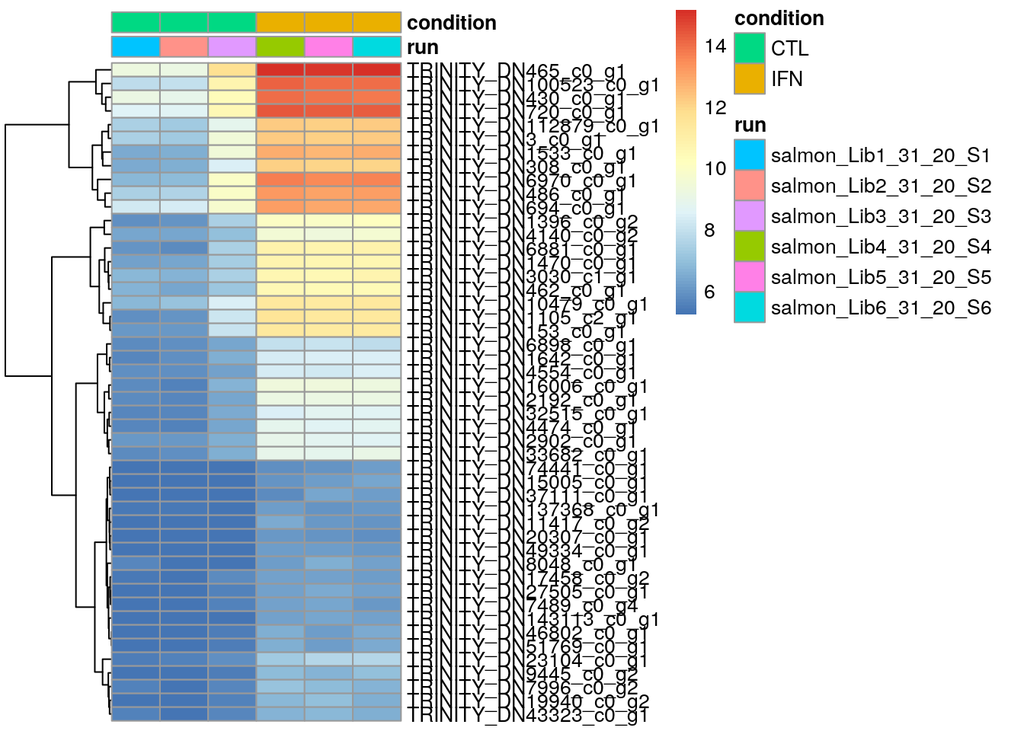

```r
#Version without the names, for the genes with abs(log2FoldChange)>4
select <- na.omit(resUsName$Row.names[resUsName$padj<0.05 & abs(resUsName$log2FoldChange)>4])
row.names(samples)=samples$run

pheatmap(assay(vsd)[select,], cluster_rows=TRUE, show_rownames=TRUE,show_colnames=FALSE,
         cluster_cols=FALSE, annotation_col=samples)
```

```r
#version with the names
#select2 <- na.omit(resUsName$Row.names[resUsName$padj<0.05 & abs(resUsName$log2FoldChange)>4])
#row.names(samples)=samples$run
#resUsNameVsd <- merge(resUsName,assay(vsd),by.x="Row.names",by.y=0)
#row.names(resUsNameVsd) <- resUsNameVsd$Row.names
#h=pheatmap(resUsNameVsd[select2,10:15], cluster_rows=TRUE, show_rownames=TRUE,show_colnames=FALSE,
#           cluster_cols=FALSE, annotation_col=samples, labels_row=resUsNameVsd[select,"external_gene_name"],fontsize_row=5)
#h
#ggsave(h,file="heatmapUpReg.png")

#Version for target selected genes
#cibles <- c("SAMD9", "SAMHD1","RNASEL","MORC3","EIF2AK2") #names of the genes of interest
#h2= pheatmap(resUsNameVsd[resUsNameVsd$external_gene_name%in%cibles,10:15], cluster_rows=TRUE, show_rownames=TRUE,show_colnames=FALSE,
#       cluster_cols=FALSE, annotation_col=samples, labels_row=resUsNameVsd[resUsNameVsd$external_gene_name%in%cibles,"external_gene_name"])
#h2
#ggsave(h2,file="heatmap_genesselected.png")
```